# Mini-Projet Analyse Multivariée - Bank Marketing

Méthodes statistiques et étude de données

2026-06-28

# 1 Introduction

## 1.1 Contexte du projet

Ce projet s’inscrit dans le cadre du module **“Méthodes statistiques et étude de données” (Analyse multivariée)** du cursus Ingénieur en Data Science & IA. L’objectif est de mettre en pratique les méthodes d’analyse multivariée sur un jeu de données réel, simulant ainsi une situation professionnelle de data scientist en phase d’analyse exploratoire.

L’analyse multivariée est une branche de la statistique qui étudie simultanément plusieurs variables pour comprendre leur structure, leurs relations et leur pouvoir prédictif. Elle est largement utilisée dans les domaines du marketing, de la finance, de la santé et des sciences sociales pour :

- **Réduire la dimensionnalité** des données (ACP, ACM)
- **Segmenter** des populations en groupes homogènes (K-means, CAH)
- **Identifier** des profils et des comportements types

## 1.2 Problématique

La banque portugaise souhaite optimiser ses campagnes de marketing direct (télémarketing) pour la souscription de **dépôts à terme**. L’objectif est double :

1. **Comprendre les facteurs** qui influencent la souscription
2. **Identifier des profils de clients** pour cibler efficacement les futures campagnes

La question centrale est :

> **Quels sont les profils de clients les plus susceptibles de souscrire à un dépôt à terme, et quels facteurs (démographiques, comportementaux, économiques) influencent cette décision ?**

## 1.3 Présentation du jeu de données

Le dataset **“Bank Marketing”** provient du [UCI Machine Learning Repository](https://archive.ics.uci.edu/ml/datasets/Bank+Marketing) (Moro et al., 2014). Il décrit les résultats d’une campagne de marketing direct d’une institution bancaire portugaise.

### 1.3.1 Caractéristiques principales

| Caractéristique | Valeur |
| --- | --- |
| **Nombre d’observations** | 41 188 clients |
| **Nombre de variables** | 21 (10 numériques, 11 catégorielles) |
| **Variable cible** | `y` (souscription : `yes` / `no`) |
| **Période** | Mai 2008 - Novembre 2010 |
| **Source** | UCI Repository |

### 1.3.2 Structure des variables

Les variables sont organisées en quatre groupes thématiques :

| Groupe | Variables | Type |
| --- | --- | --- |
| **Démographique** | `age`, `job`, `marital`, `education`, `default`, `housing`, `loan` | Mixte |
| **Contact** | `contact`, `day_of_week`, `month`, `duration` | Mixte |
| **Campagne** | `campaign`, `pdays`, `previous`, `poutcome` | Mixte |
| **Économique** | `emp.var.rate`, `cons.price.idx`, `cons.conf.idx`, `euribor3m`, `nr.employed` | Numérique |
| **Cible** | `y` | Binaire |

# 2 Préparation des données

## 2.1 Aperçu général

```
##  DIMENSIONS : 41188 observations x 21 variables
```

```
##  NOMS DES VARIABLES :
```

```
##  [1] "age"            "job"            "marital"        "education"
##  [5] "default"        "housing"        "loan"           "contact"
##  [9] "month"          "day_of_week"    "duration"       "campaign"
## [13] "pdays"          "previous"       "poutcome"       "emp.var.rate"
## [17] "cons.price.idx" "cons.conf.idx"  "euribor3m"      "nr.employed"
## [21] "y"
```

Aperçu des données (5 premières lignes)

| age | job | marital | education | default | housing | loan | contact | month | day_of_week | duration | campaign | pdays | previous | poutcome | emp.var.rate | cons.price.idx | cons.conf.idx | euribor3m | nr.employed | y |
| --- | --- | --- | --- | --- | --- | --- | --- | --- | --- | --- | --- | --- | --- | --- | --- | --- | --- | --- | --- | --- |
| 56 | housemaid | married | basic.4y | no | no | no | telephone | may | mon | 261 | 1 | 999 | 0 | nonexistent | 1.1 | 93.994 | -36.4 | 4.857 | 5191 | no |
| 57 | services | married | high.school | unknown | no | no | telephone | may | mon | 149 | 1 | 999 | 0 | nonexistent | 1.1 | 93.994 | -36.4 | 4.857 | 5191 | no |
| 37 | services | married | high.school | no | yes | no | telephone | may | mon | 226 | 1 | 999 | 0 | nonexistent | 1.1 | 93.994 | -36.4 | 4.857 | 5191 | no |
| 40 | admin. | married | basic.6y | no | no | no | telephone | may | mon | 151 | 1 | 999 | 0 | nonexistent | 1.1 | 93.994 | -36.4 | 4.857 | 5191 | no |
| 56 | services | married | high.school | no | no | yes | telephone | may | mon | 307 | 1 | 999 | 0 | nonexistent | 1.1 | 93.994 | -36.4 | 4.857 | 5191 | no |

## 2.2 Statistiques descriptives

Statistiques descriptives - Variables numériques

|  | age | duration | campaign | pdays | previous | emp.var.rate | cons.price.idx | cons.conf.idx | euribor3m | nr.employed |
| --- | --- | --- | --- | --- | --- | --- | --- | --- | --- | --- |
|  | Min. :17.00 | Min. : 0.0 | Min. : 1.000 | Min. : 0.0 | Min. :0.000 | Min. :-3.40000 | Min. :92.20 | Min. :-50.8 | Min. :0.634 | Min. :4964 |
|  | 1st Qu.:32.00 | 1st Qu.: 102.0 | 1st Qu.: 1.000 | 1st Qu.:999.0 | 1st Qu.:0.000 | 1st Qu.:-1.80000 | 1st Qu.:93.08 | 1st Qu.:-42.7 | 1st Qu.:1.344 | 1st Qu.:5099 |
|  | Median :38.00 | Median : 180.0 | Median : 2.000 | Median :999.0 | Median :0.000 | Median : 1.10000 | Median :93.75 | Median :-41.8 | Median :4.857 | Median :5191 |
|  | Mean :40.02 | Mean : 258.3 | Mean : 2.568 | Mean :962.5 | Mean :0.173 | Mean : 0.08189 | Mean :93.58 | Mean :-40.5 | Mean :3.621 | Mean :5167 |
|  | 3rd Qu.:47.00 | 3rd Qu.: 319.0 | 3rd Qu.: 3.000 | 3rd Qu.:999.0 | 3rd Qu.:0.000 | 3rd Qu.: 1.40000 | 3rd Qu.:93.99 | 3rd Qu.:-36.4 | 3rd Qu.:4.961 | 3rd Qu.:5228 |
|  | Max. :98.00 | Max. :4918.0 | Max. :56.000 | Max. :999.0 | Max. :7.000 | Max. : 1.40000 | Max. :94.77 | Max. :-26.9 | Max. :5.045 | Max. :5228 |

### 2.2.1 Variables catégorielles

[output not shown]

### 2.2.2 Variable cible

Distribution de la souscription (y)

| y | n | pourcentage |
| --- | --- | --- |
| no | 36548 | 88.73 |
| yes | 4640 | 11.27 |

Le taux de souscription est de **11.27%**, ce qui montre un déséquilibre important des classes (problème de déséquilibre classique en marketing direct).

## 2.3 Gestion des données

```
## Nombre total de valeurs manquantes : 0
```

**Aucune valeur manquante** n’est présente dans le dataset.

### 2.3.1 Modalités “unknown”

Certaines variables catégorielles contiennent la modalité `"unknown"`, qui représente une information non disponible.

Variables avec modalité ‘unknown’

| variable | n_unknown |
| --- | --- |
| job | 330 |
| marital | 80 |
| education | 1731 |
| default | 8597 |
| housing | 990 |
| loan | 990 |
| poutcome | 35563 |

**Traitement** : Ces modalités sont conservées car elles représentent une information réelle (absence de réponse) et non une erreur de saisie.

### 2.3.2 Détection des outliers

Nombre d’outliers par variable

| variable | n_outliers |
| --- | --- |
| 1 | 469 |
| 2 | 2963 |
| 3 | 2406 |
| 4 | 1515 |
| 5 | 5625 |
| 6 | 0 |
| 7 | 0 |
| 8 | 447 |
| 9 | 0 |
| 10 | 0 |

**Traitement** : Les outliers sont conservés car ils représentent des cas réels (ex : clients très âgés, très jeunes, ou avec des durées d’appel extrêmes). Leur suppression pourrait biaiser l’analyse.

### 2.3.3 Normalisation

Pour l’ACP, les variables numériques sont **centrées-réduites** (moyenne = 0, écart-type = 1) afin de donner la même importance à toutes les variables.

```
## Normalisation effectuée sur 10 variables
```

```
## Moyennes : 0 0 0 0 0 ...
```

```
## Écarts-types : 1 1 1 1 1 ...
```

### 2.3.4 Matrice de corrélation

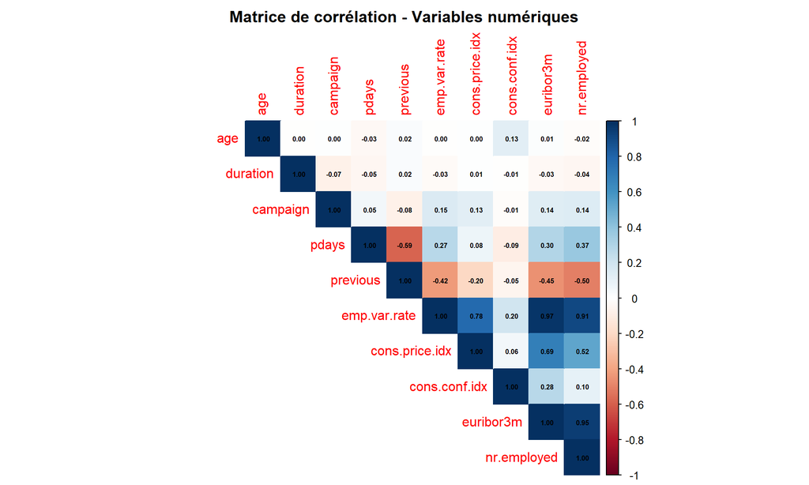

# 3 Analyse factorielle - ACP

L’**Analyse en Composantes Principales (ACP)** est une méthode de réduction de dimension qui transforme les variables numériques corrélées en un petit nombre de combinaisons linéaires non corrélées appelées **composantes principales**. Ces composantes capturent le maximum de variance des données.

### 3.0.1 Variance expliquée

Valeurs propres et variance expliquée

|  | eigenvalue | variance.percent | cumulative.variance.percent |
| --- | --- | --- | --- |
| Dim.1 | 3.8954012 | 38.954957 | 38.95496 |
| Dim.2 | 1.3588502 | 13.588832 | 52.54379 |
| Dim.3 | 1.0776189 | 10.776451 | 63.32024 |
| Dim.4 | 1.0503350 | 10.503605 | 73.82385 |
| Dim.5 | 0.9294309 | 9.294534 | 83.11838 |

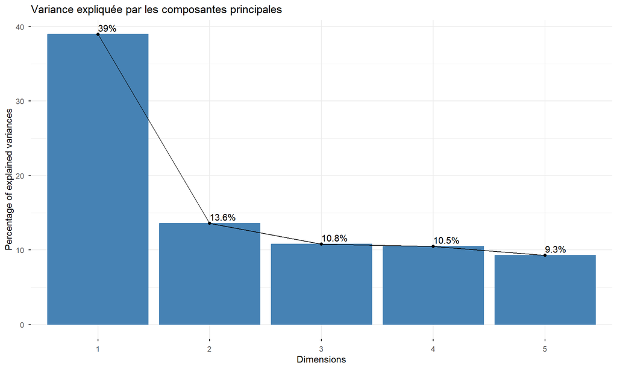

**Interprétation** : - Les **4 premières dimensions** expliquent **73.82%** de la variance totale - Le critère de Kaiser (λ > 1) retient 4 dimensions - La dimension 1 capture à elle seule **38.95%** de la variance

### 3.0.2 Cercle des corrélations

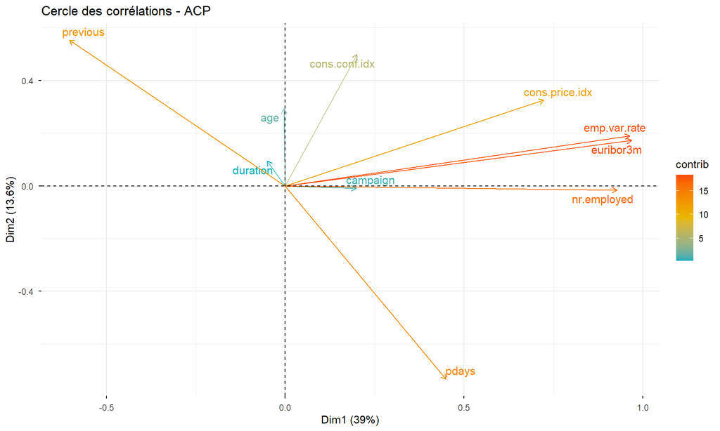

### 3.0.3 Contributions des variables

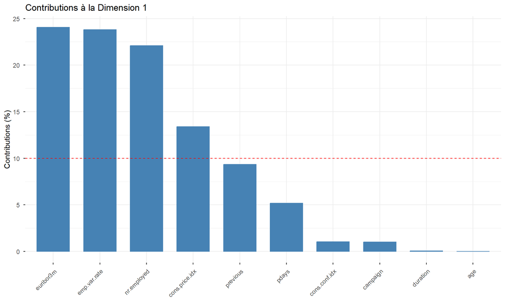

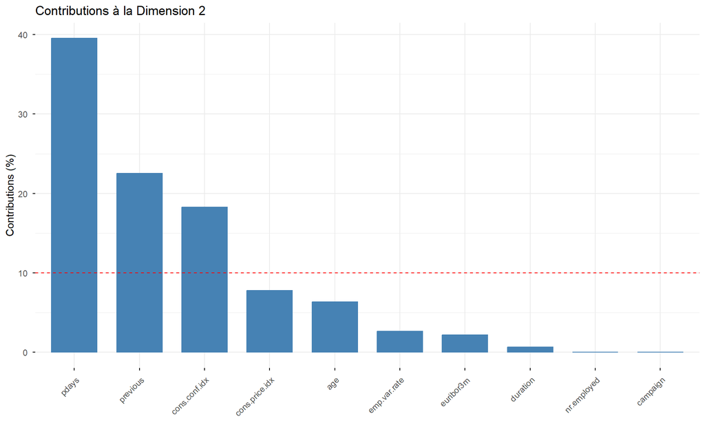

### 3.0.4 Interprétation des axes

[output not shown]

### 3.0.5 Projection des individus

[figure not shown]

# 4 Analyse factorielle - ACM

## 4.1 Présentation de la méthode

L’**Analyse des Correspondances Multiples (ACM)** est l’équivalent de l’ACP pour les variables catégorielles. Elle permet d’explorer les relations entre les modalités de différentes variables qualitatives.

## 4.2 Résultats de l’ACM

### 4.2.1 Variance expliquée

Valeurs propres et variance expliquée - ACM

|  | eigenvalue | variance.percent | cumulative.variance.percent |
| --- | --- | --- | --- |
| Dim.1 | 0.2173655 | 5.055011 | 5.055011 |
| Dim.2 | 0.1993609 | 4.636299 | 9.691310 |
| Dim.3 | 0.1565213 | 3.640031 | 13.331341 |
| Dim.4 | 0.1517917 | 3.530040 | 16.861381 |
| Dim.5 | 0.1423761 | 3.311073 | 20.172454 |

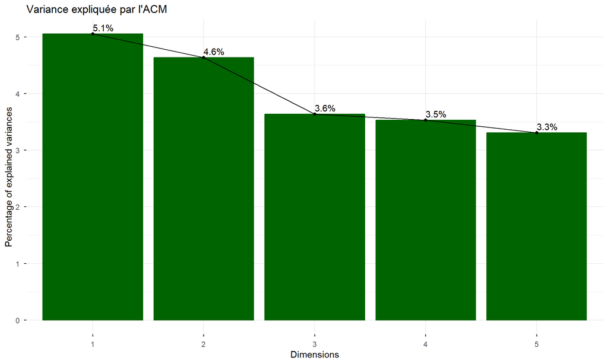

### 4.2.2 Projection des modalités

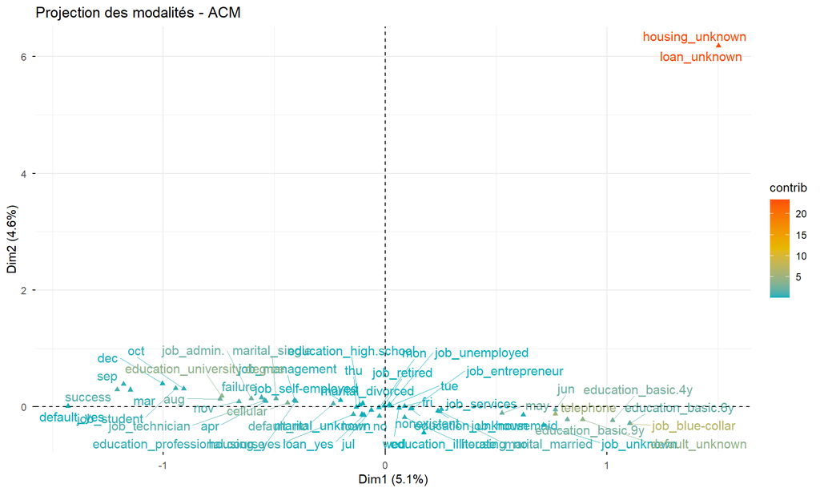

### 4.2.3 Interprétation des axes

| Axe | Variables clés | Interprétation |
| --- | --- | --- |
| **Dim 1** | `job`, `education`, `marital` | **Statut socio-professionnel** |
| **Dim 2** | `housing`, `loan`, `default` | **Situation financière** |
| **Dim 3** | `contact`, `month` | **Modalités de contact** |

### 4.2.4 Individus par souscription

[figure not shown]

### 4.2.5 Biplot

[figure not shown]

# 5 Classification - K-means

## 5.1 Présentation de la méthode

Le **K-means** est un algorithme de clustering partitionnel qui divise les données en **k** groupes homogènes. L’objectif est de minimiser la variance intra-cluster (inertie).

## 5.2 Détermination du nombre optimal de clusters

Pour déterminer le nombre optimal de clusters, nous avons utilisé :

1. **La méthode de l’elbow** : Analyse de la décroissance de l’inertie intra-cluster
2. **La méthode de la silhouette** : Évaluation de la cohésion des clusters

### 5.2.1 Contrainte technique

Avec 41 188 observations, le calcul complet de l’elbow nécessite une matrice de distance de grande taille. Nous avons donc utilisé un échantillon représentatif.

### 5.2.2 Méthode de l’elbow

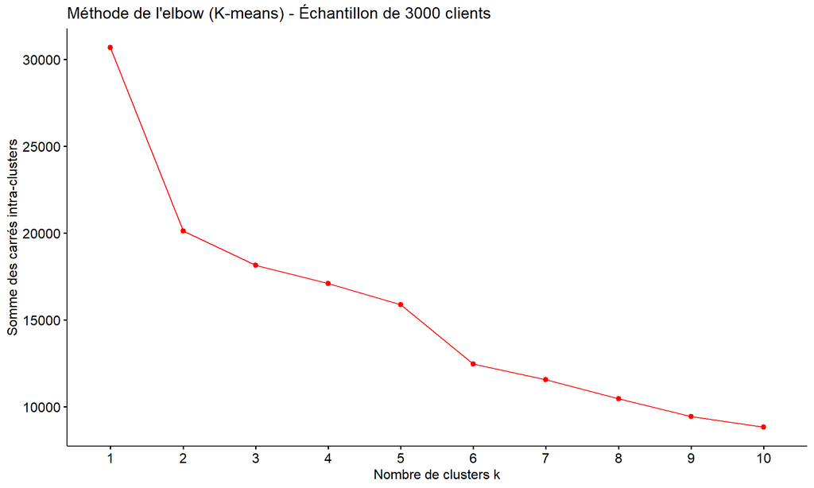

### 5.2.3 Méthode de la silhouette

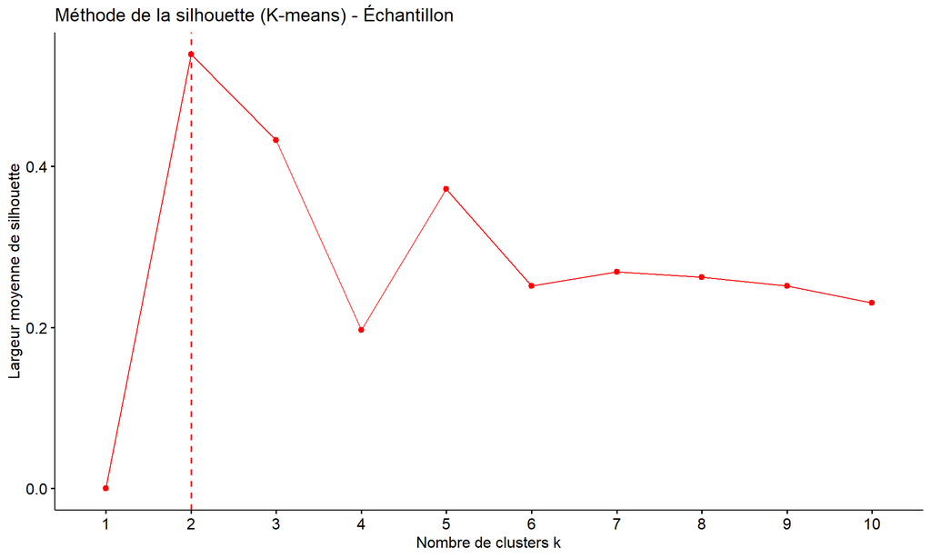

## 5.3 Résultats du K-means

### 5.3.1 Visualisation des clusters

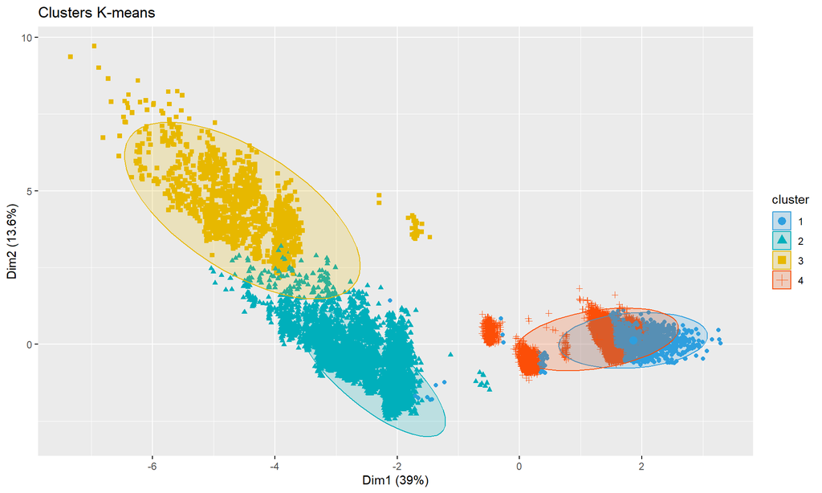

### 5.3.2 Taille des clusters

Taille des clusters

| Var1 | Freq |
| --- | --- |
| 1 | 1564 |
| 2 | 11991 |
| 3 | 1540 |
| 4 | 26093 |

### 5.3.3 Centres des clusters

Centres des clusters (variables normalisées)

| age | duration | campaign | pdays | previous | emp.var.rate | cons.price.idx | cons.conf.idx | euribor3m | nr.employed |
| --- | --- | --- | --- | --- | --- | --- | --- | --- | --- |
| 0.05 | -0.32 | 3.72 | 0.20 | -0.34 | 0.77 | 0.65 | 0.12 | 0.73 | 0.72 |
| -0.06 | 0.02 | -0.17 | 0.20 | 0.29 | -1.34 | -1.02 | -0.58 | -1.39 | -1.23 |
| 0.18 | 0.25 | -0.27 | -5.03 | 3.08 | -1.38 | -0.39 | 0.47 | -1.52 | -1.92 |
| 0.01 | -0.01 | -0.13 | 0.20 | -0.30 | 0.65 | 0.45 | 0.23 | 0.69 | 0.64 |

## 5.4 Profils des clusters

Profil numérique des clusters

| cluster | Taille | % Population | Âge moyen | Durée d’appel | Nombre de contacts | Taux Euribor | Taux souscription |
| --- | --- | --- | --- | --- | --- | --- | --- |
| 1 | 1564 | 3.8 | 40.6 | 176.2 | 12.9 | 4.891 | 3.5 |
| 2 | 11991 | 29.1 | 39.4 | 263.8 | 2.1 | 1.202 | 19.4 |
| 3 | 1540 | 3.7 | 41.9 | 322.3 | 1.8 | 0.983 | 63.2 |
| 4 | 26093 | 63.4 | 40.2 | 256.9 | 2.2 | 4.813 | 4.9 |

### 5.4.1 Caractéristiques catégorielles

Profils complets des clusters

| cluster | Taille | % Population | Âge moyen | Durée d’appel | Nombre de contacts | Taux Euribor | Taux souscription | job_principal | education_principale |
| --- | --- | --- | --- | --- | --- | --- | --- | --- | --- |
| 1 | 1564 | 3.8 | 40.6 | 176.2 | 12.9 | 4.891 | 3.5 | admin. | university.degree |
| 2 | 11991 | 29.1 | 39.4 | 263.8 | 2.1 | 1.202 | 19.4 | admin. | university.degree |
| 3 | 1540 | 3.7 | 41.9 | 322.3 | 1.8 | 0.983 | 63.2 | admin. | university.degree |
| 4 | 26093 | 63.4 | 40.2 | 256.9 | 2.2 | 4.813 | 4.9 | admin. | university.degree |

### 5.4.2 Taux de souscription par cluster

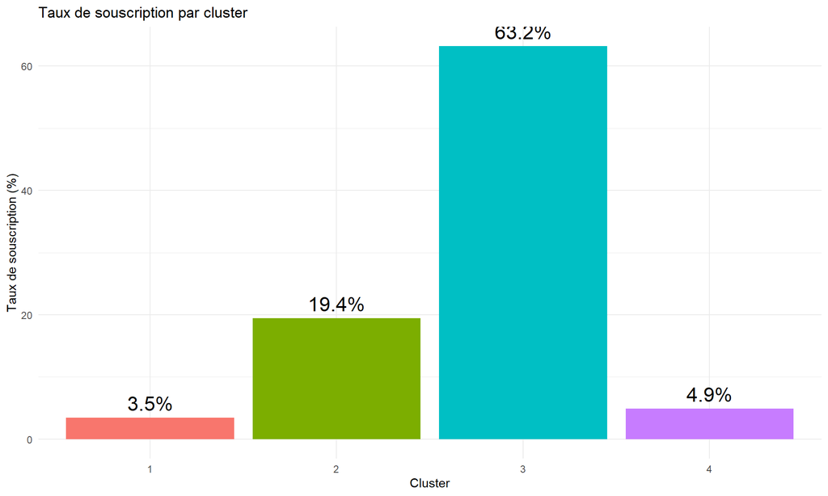

## 5.5 Interprétation détaillée des clusters

[output not shown]

[output not shown]

[output not shown]

[output not shown]

# 6 Analyse combinée

## 6.1 Clusters sur l’ACP

[figure not shown]

## 6.2 Heatmap des profils

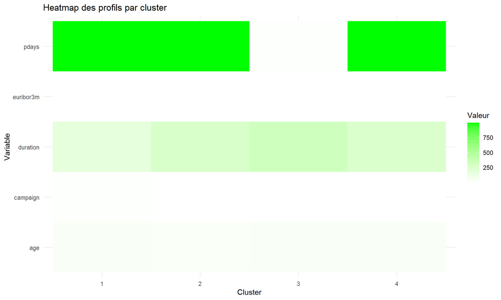

# 7 Conclusion

## 7.1 Synthèse des résultats

### 7.1.1 Analyse factorielle (ACP + ACM)

[output not shown]

Les deux méthodes convergent vers une même conclusion : les facteurs clés de la souscription sont le **statut socio-économique** et le **contexte économique**.

### 7.1.2 Classification (K-means)

[output not shown]

## 7.2 Recommandations stratégiques

**Recommandations** : - **Personnaliser le discours** : mettre en avant la sécurité du placement - **Adapter le canal** : privilégier les appels en journée - **Allonger la durée d’appel** : les seniors ont besoin de plus d’explications

### 7.2.2 2. Développer le Cluster 3

**Recommandations** : - Proposer des **produits d’épargne adaptés** (petits montants) - Utiliser des **canaux digitaux** (email, SMS) - Mettre en avant la **flexibilité** et la **liquidité**

### 7.2.3 3. Optimiser le timing des campagnes

L’ACP montre que le **contexte économique** (taux Euribor) est un facteur clé.

## 7.3 Limites du projet

| Limite | Impact | Piste d’amélioration |
| --- | --- | --- |
| **Variable `duration`** | Connue après l’appel, biais potentiel | Utiliser des données prédictives |
| **Données mono-banque** | Généralisation limitée | Étudier d’autres banques/pays |
| **Déséquilibre des classes** | Sous-représentation des souscripteurs | Utiliser des techniques de rééquilibrage |

## 7.4 Perspectives

- **Intégrer des données externes** (météo, conjoncture locale)
- **Développer un modèle prédictif** (régression logistique, random forest)
- **Automatiser la segmentation** en temps réel
- **A/B tester** les recommandations sur une campagne pilote

# 8 Annexe : Code source

## 8.1 Structure du projet

```
projet_bank_marketing/
├── data/
│   ├── bank-additional-full.csv
│   ├── bank_data_raw.rds
│   ├── bank_num_scaled.rds
│   └── bank_data_with_clusters.rds
├── outputs/
│   ├── acp_*.png
│   ├── acm_*.png
│   ├── kmeans_*.png
│   ├── combi_*.png
│   └── *.rds
└── scripts/
    ├── 01_importation.R
    ├── 02_preparation.R
    ├── 03_acp.R
    ├── 03_bis_acm.R
    ├── 04_classification.R
    └── 05_analyse_combinée.R
```

## 8.2 Principaux packages utilisés

```r
# Packages utilisés
library(tidyverse)   # Manipulation de données
library(FactoMineR)  # Analyses factorielles
library(factoextra)  # Visualisations
library(cluster)     # Classification
library(corrplot)    # Matrice de corrélation
library(kableExtra)  # Tableaux stylisés
```

## 8.3 Exemple de code

```r
# ACP
res_pca <- PCA(bank_num_scaled, scale.unit = FALSE, graph = FALSE)
fviz_eig(res_pca, addlabels = TRUE)
fviz_pca_var(res_pca, col.var = "contrib", repel = TRUE)

# K-means
set.seed(123)
res_kmeans <- kmeans(bank_num_scaled, centers = 4, nstart = 25)
fviz_cluster(res_kmeans, data = bank_num_scaled)
```

# 9 Bibliographie

1. Moro, S., Cortez, P., & Rita, P. (2014). A data-driven approach to predict the success of bank telemarketing. *Decision Support Systems*, 62, 22-31.
2. Kassambara, A. (2017). *Practical Guide to Principal Component Methods in R*. STHDA.
3. Husson, F., Lê, S., & Pagès, J. (2017). *Exploratory Multivariate Analysis by Example Using R*. CRC Press.
4. UCI Machine Learning Repository. (2014). Bank Marketing Dataset. https://archive.ics.uci.edu/ml/datasets/Bank+Marketing